# Chapter 3 - Applied Exercises

5. Use the `*` and `:` symbols to fit linear regression models with interaction effects. Do any interactions appear to be statistically significant?

Since `year` and `weight` have the most statistically significant coefficents in the model from part (c), we will start by fitting a linear model with their values and their first order interaction term.

```r
int_lm_1 <- lm(mpg ~ year * weight, data = Auto)
summary(int_lm_1)
```

```
##
## Call:
## lm(formula = mpg ~ year * weight, data = Auto)
##
## Residuals:
##     Min      1Q  Median      3Q     Max
## -8.0397 -1.9956 -0.0983  1.6525 12.9896
##
## Coefficients:
##               Estimate Std. Error t value Pr(>|t|)
## (Intercept) -1.105e+02  1.295e+01  -8.531 3.30e-16 ***
## year         2.040e+00  1.718e-01  11.876  < 2e-16 ***
## weight       2.755e-02  4.413e-03   6.242 1.14e-09 ***
## year:weight -4.579e-04  5.907e-05  -7.752 8.02e-14 ***
## ---
## Signif. codes:  0 '***' 0.001 '**' 0.01 '*' 0.05 '.' 0.1 ' ' 1
##
## Residual standard error: 3.193 on 388 degrees of freedom
## Multiple R-squared:  0.8339, Adjusted R-squared:  0.8326
## F-statistic: 649.3 on 3 and 388 DF,  p-value: < 2.2e-16
```

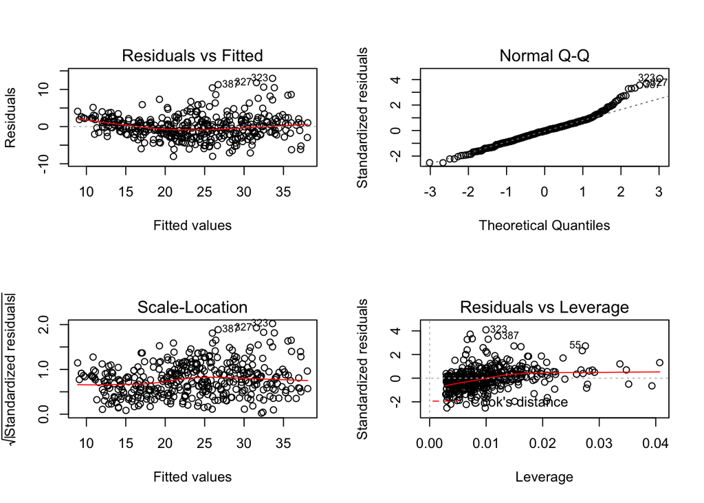

```r
par(mfrow = c(2,2))
plot(int_lm_1)
```

```r
par(mfrow = c(1,1))
```

The R-squared statistic is slightly higher than the model from (c), indicating that more of the variability in `mpg` can be explained by this model.

Let’s see how good the fit is if we just include `year` and `weight` without the interaction term:

```r
int_lm_2 <- lm(mpg ~ year + weight, data = Auto)
summary(int_lm_2)
```

```
##
## Call:
## lm(formula = mpg ~ year + weight, data = Auto)
##
## Residuals:
##     Min      1Q  Median      3Q     Max
## -8.8505 -2.3014 -0.1167  2.0367 14.3555
##
## Coefficients:
##               Estimate Std. Error t value Pr(>|t|)
## (Intercept) -1.435e+01  4.007e+00  -3.581 0.000386 ***
## year         7.573e-01  4.947e-02  15.308  < 2e-16 ***
## weight      -6.632e-03  2.146e-04 -30.911  < 2e-16 ***
## ---
## Signif. codes:  0 '***' 0.001 '**' 0.01 '*' 0.05 '.' 0.1 ' ' 1
##
## Residual standard error: 3.427 on 389 degrees of freedom
## Multiple R-squared:  0.8082, Adjusted R-squared:  0.8072
## F-statistic: 819.5 on 2 and 389 DF,  p-value: < 2.2e-16
```

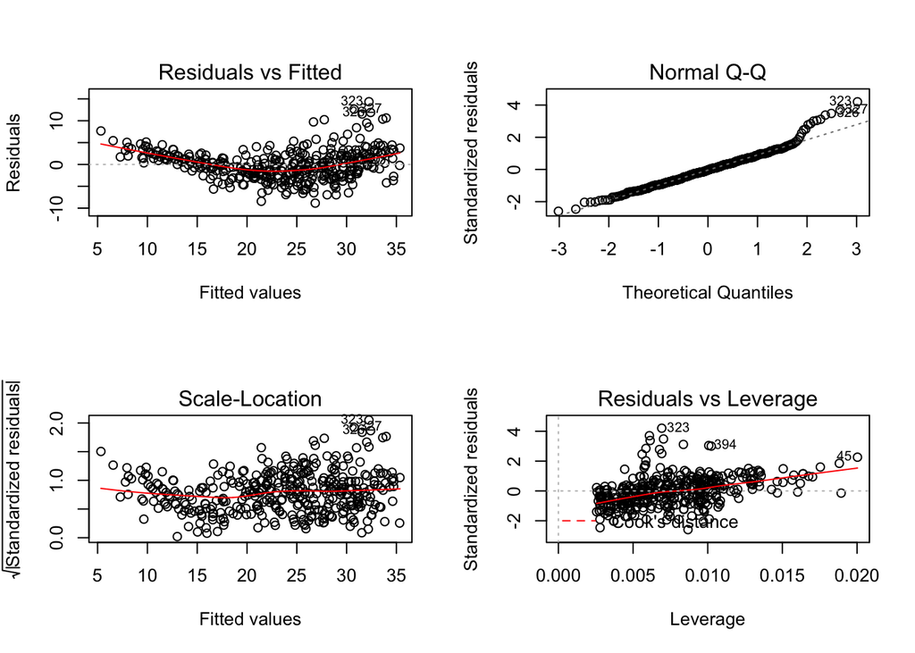

```r
par(mfrow = c(2,2))
plot(int_lm_2)
```

```r
par(mfrow = c(1,1))
```

Slightly lower R-squared value than the model with the interaction term.

Lastly, let’s see how the model from (c) does with the inclusion of the interaction term

```r
int_lm_3 <- lm(mpg ~ . - name + year:weight, data = Auto)
summary(int_lm_3)
```

```
##
## Call:
## lm(formula = mpg ~ . - name + year:weight, data = Auto)
##
## Residuals:
##     Min      1Q  Median      3Q     Max
## -7.9995 -1.8495 -0.1559  1.6061 11.7042
##
## Coefficients:
##                Estimate Std. Error t value Pr(>|t|)
## (Intercept)  -1.186e+02  1.338e+01  -8.864  < 2e-16 ***
## cylinders    -1.218e-01  3.032e-01  -0.402   0.6881
## displacement  1.293e-02  7.019e-03   1.842   0.0663 .
## horsepower   -2.877e-02  1.286e-02  -2.236   0.0259 *
## weight        3.044e-02  4.652e-03   6.543 1.94e-10 ***
## acceleration  1.447e-01  9.196e-02   1.574   0.1164
## year          2.084e+00  1.732e-01  12.033  < 2e-16 ***
## origin        1.174e+00  2.597e-01   4.519 8.30e-06 ***
## weight:year  -4.879e-04  6.097e-05  -8.002 1.47e-14 ***
## ---
## Signif. codes:  0 '***' 0.001 '**' 0.01 '*' 0.05 '.' 0.1 ' ' 1
##
## Residual standard error: 3.084 on 383 degrees of freedom
## Multiple R-squared:  0.847,  Adjusted R-squared:  0.8439
## F-statistic: 265.1 on 8 and 383 DF,  p-value: < 2.2e-16
```

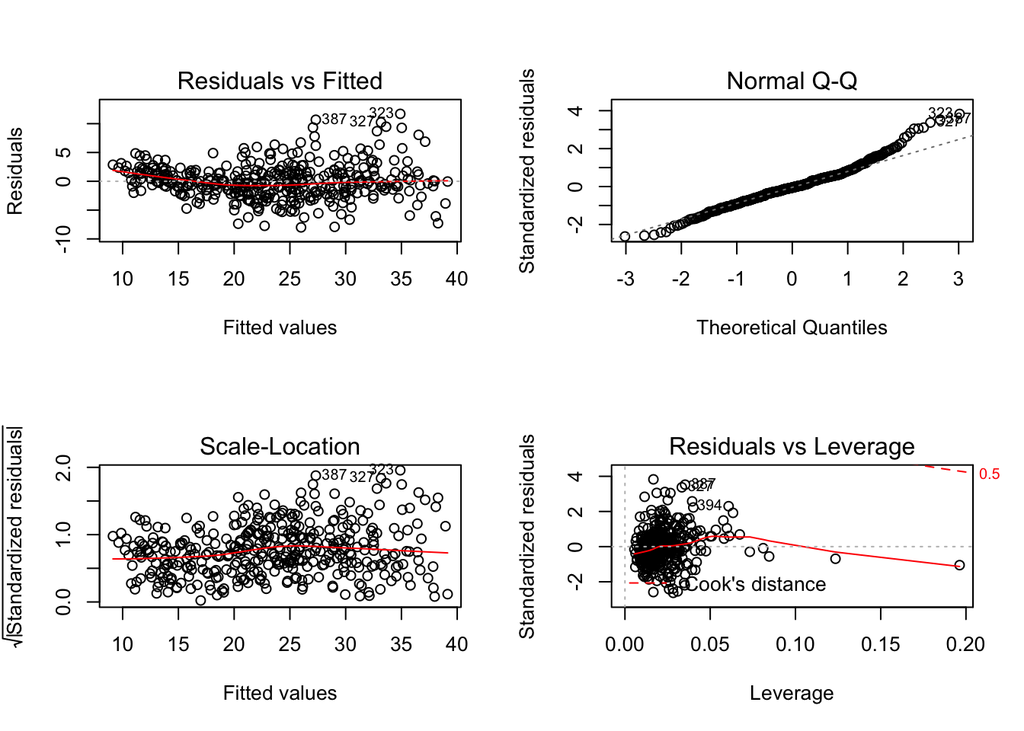

```r
par(mfrow = c(2,2))
plot(int_lm_3)
```

```r
par(mfrow = c(1,1))
```

The R-squared value is further improved. However, the model fit with just `year`, `weight`, and their interaction term is so close to the model above and the model from (c) that we are prone to stick with the simpler model for its interpretability and graphability.

6. Try a few different transformations of the variables, such as `log(X)`, `sqrt{X}`, `X^2`.

```r
square_lm <- lm(mpg ~ year + I(year^2) + weight + I(weight^2), data = Auto)
summary(square_lm)
```

```
##
## Call:
## lm(formula = mpg ~ year + I(year^2) + weight + I(weight^2), data = Auto)
##
## Residuals:
##     Min      1Q  Median      3Q     Max
## -9.0691 -1.8215  0.0464  1.4002 13.1148
##
## Coefficients:
##               Estimate Std. Error t value Pr(>|t|)
## (Intercept)  3.551e+02  6.964e+01   5.100 5.33e-07 ***
## year        -8.506e+00  1.839e+00  -4.625 5.12e-06 ***
## I(year^2)    6.143e-02  1.210e-02   5.077 5.98e-07 ***
## weight      -2.115e-02  1.399e-03 -15.113  < 2e-16 ***
## I(weight^2)  2.300e-06  2.182e-07  10.540  < 2e-16 ***
## ---
## Signif. codes:  0 '***' 0.001 '**' 0.01 '*' 0.05 '.' 0.1 ' ' 1
##
## Residual standard error: 2.939 on 387 degrees of freedom
## Multiple R-squared:  0.8596, Adjusted R-squared:  0.8582
## F-statistic: 592.4 on 4 and 387 DF,  p-value: < 2.2e-16
```

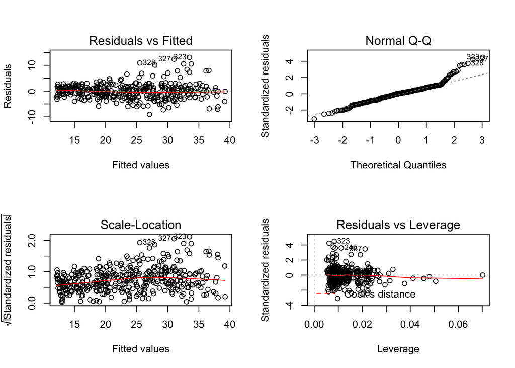

```r
par(mfrow = c(2,2))
plot(square_lm)
```

```r
par(mfrow = c(1,1))
```

#### 10. This question should be answered using the `Carseats` data set.

```r
glimpse(Carseats)
```

```
## Observations: 400
## Variables: 11
## $ Sales       <dbl> 9.50, 11.22, 10.06, 7.40, 4.15, 10.81, 6.63, 11.85, …
## $ CompPrice   <dbl> 138, 111, 113, 117, 141, 124, 115, 136, 132, 132, 12…
## $ Income      <dbl> 73, 48, 35, 100, 64, 113, 105, 81, 110, 113, 78, 94,…
## $ Advertising <dbl> 11, 16, 10, 4, 3, 13, 0, 15, 0, 0, 9, 4, 2, 11, 11, …
## $ Population  <dbl> 276, 260, 269, 466, 340, 501, 45, 425, 108, 131, 150…
## $ Price       <dbl> 120, 83, 80, 97, 128, 72, 108, 120, 124, 124, 100, 9…
## $ ShelveLoc   <fct> Bad, Good, Medium, Medium, Bad, Bad, Medium, Good, M…
## $ Age         <dbl> 42, 65, 59, 55, 38, 78, 71, 67, 76, 76, 26, 50, 62, …
## $ Education   <dbl> 17, 10, 12, 14, 13, 16, 15, 10, 10, 17, 10, 13, 18, …
## $ Urban       <fct> Yes, Yes, Yes, Yes, Yes, No, Yes, Yes, No, No, No, Y…
## $ US          <fct> Yes, Yes, Yes, Yes, No, Yes, No, Yes, No, Yes, Yes, …
```

1. Fit a regression model to predict `Sales` using `Price`, `Urban`, and `US`.

```r
my_lm <- lm(Sales ~ Price + Urban + US, data = Carseats)
summary(my_lm)
```

```
##
## Call:
## lm(formula = Sales ~ Price + Urban + US, data = Carseats)
##
## Residuals:
##     Min      1Q  Median      3Q     Max
## -6.9206 -1.6220 -0.0564  1.5786  7.0581
##
## Coefficients:
##              Estimate Std. Error t value Pr(>|t|)
## (Intercept) 13.043469   0.651012  20.036  < 2e-16 ***
## Price       -0.054459   0.005242 -10.389  < 2e-16 ***
## UrbanYes    -0.021916   0.271650  -0.081    0.936
## USYes        1.200573   0.259042   4.635 4.86e-06 ***
## ---
## Signif. codes:  0 '***' 0.001 '**' 0.01 '*' 0.05 '.' 0.1 ' ' 1
##
## Residual standard error: 2.472 on 396 degrees of freedom
## Multiple R-squared:  0.2393, Adjusted R-squared:  0.2335
## F-statistic: 41.52 on 3 and 396 DF,  p-value: < 2.2e-16
```

2. Provide an interpretation of each coefficient in the model.

To interpret this result, lets look at the coding the `R` uses for the dummy variables:

```r
contrasts(Carseats$US)
```

```
##     Yes
## No    0
## Yes   1
```

```r
contrasts(Carseats$Urban)
```

```
##     Yes
## No    0
## Yes   1
```

`R` has created two dummy variables – `USYes` and `UrbanYes` – that take on the value 1 if `US = Yes` or `Urban = Yes`, respectively.

The p-value of the model from (a) is statistically significant, indicating some relationship between the predictors and the response. The p value for the `UrbanYes` coefficient is not statistically significant, but the p values for `Price` and `USYes` are. The standard error for these two coefficients is small enough that their confidence intervals keep the same sign as the estimate of the coefficient. That is, we can be confident that `Price` has a slight negative relationship with `Sales` – the more expensive the care, the less it will sell. We can be confident that for observations where `US = Yes`, the car will sell more units than if `US = No`.

4. For which of the predictors can you reject the null hypothesis?

We can reject the null hypothesis for `Price` and `USYes` with a signficane level of 0.001.

5. On the basis of your response to the previous question, fit a smaller model that uses only the predictors for which there is evidence of association with the outcome.

```r
lm_10e <- lm(Sales ~ Price + US, data = Carseats)
summary(lm_10e)
```

```
##
## Call:
## lm(formula = Sales ~ Price + US, data = Carseats)
##
## Residuals:
##     Min      1Q  Median      3Q     Max
## -6.9269 -1.6286 -0.0574  1.5766  7.0515
##
## Coefficients:
##             Estimate Std. Error t value Pr(>|t|)
## (Intercept) 13.03079    0.63098  20.652  < 2e-16 ***
## Price       -0.05448    0.00523 -10.416  < 2e-16 ***
## USYes        1.19964    0.25846   4.641 4.71e-06 ***
## ---
## Signif. codes:  0 '***' 0.001 '**' 0.01 '*' 0.05 '.' 0.1 ' ' 1
##
## Residual standard error: 2.469 on 397 degrees of freedom
## Multiple R-squared:  0.2393, Adjusted R-squared:  0.2354
## F-statistic: 62.43 on 2 and 397 DF,  p-value: < 2.2e-16
```

6. How well do the models in (a) and (e) fit the data?

Recall that the residual standard error, RSE, can be interpreted as the average amount the the predicted result will deviate from the regression line. Let’s calculate what percentage error this in on average using the RSE value from (e):

```r
100 * round(2.469/mean(Carseats$Sales), 2)
```

```
## [1] 33
```

On average, the prediction will have an error of 33%. This is not a terrible amount of error, but it is not great.

The R-squared values for both are less than 25% – in both (a) and (e), less than a quarter of the variability of `Sales` is explained by the model.

7. Using the model from (e), obtain 95% confidence intervals for the coefficients.

Recall that a 95% confidence interval for a coefficient in a linear model is `(coeff - 2 * std. error, coeff + 2 * std. error)`. Then `(`11.77`,`14.29`)` is the 95% confidence interval for the Intercept, `(`-0.065`,`-0.045`)` for `Price`, and `(`0.68`,`1.72`)` for `US`.

8. Is there evidence of outliers or high leverage observations in the model from (e)?

Let’s look at the diagnostic plots:

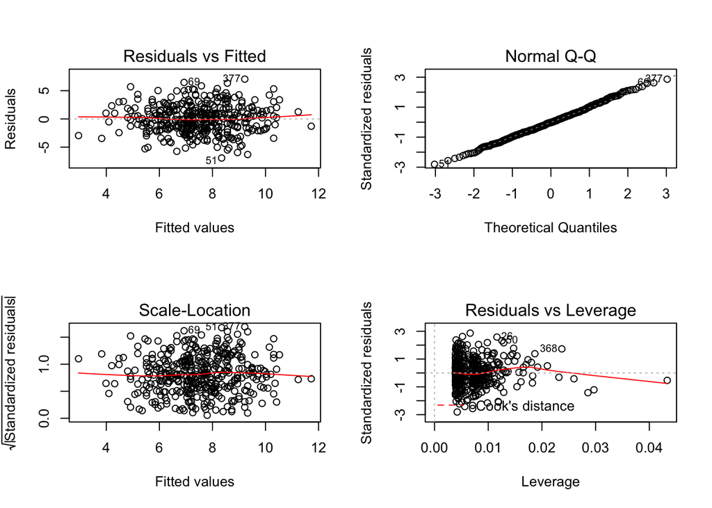

```r
par(mfrow = c(2,2))
plot(lm_10e)
```

```r
par(mfrow = c(1,1))
```

There are no observations with standardized residuals outside of the rule of thumb range of (-3, 3), indicating an absence of outliers. There is one observation with much more leverage than the remaining observations, but its leverage value is still small.

#### 11. Investigate the t-statistic for the null hypothesis in simple linear regression.

To begin, we generate a predictor `x` and a response `y` as follows.

```r
set.seed(1)
x = rnorm(100)
y = 2*x + rnorm(100)
```

Let’s take a look at what we’ve generated:

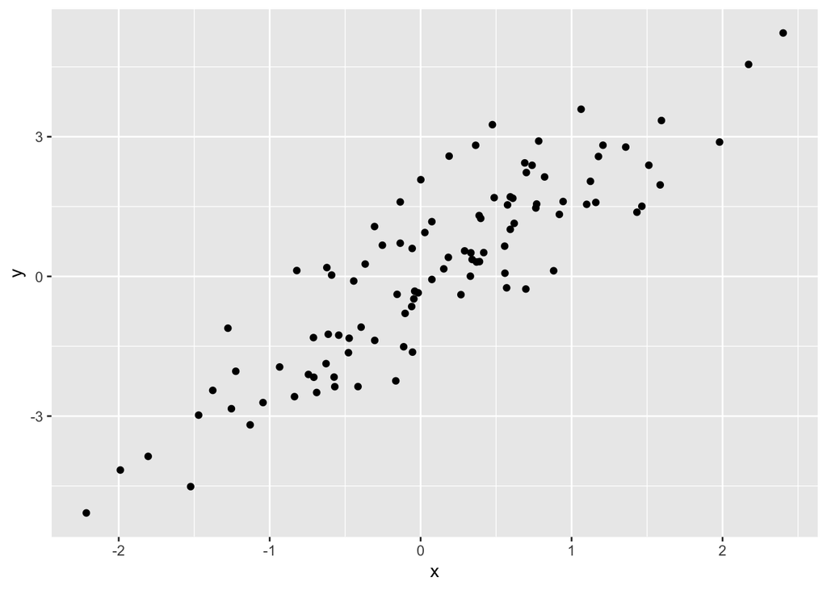

```r
ggplot(data.frame(x = x, y = y), aes(x = x, y = y)) + geom_point()
```

1. Perform a simple linear regression of `y` onto `x`, without an intercept. Report the coefficient estimate, the standard error of the coefficient estimate, and the t-statistic and the p-value associated with the null hypothesis.

To perform regression without an intercept, add `+ 0` or `- 1` to the formula.

```r
lm_11a <- lm(y ~ x + 0)
summary(lm_11a)
```

```
##
## Call:
## lm(formula = y ~ x + 0)
##
## Residuals:
##     Min      1Q  Median      3Q     Max
## -1.9154 -0.6472 -0.1771  0.5056  2.3109
##
## Coefficients:
##   Estimate Std. Error t value Pr(>|t|)
## x   1.9939     0.1065   18.73   <2e-16 ***
## ---
## Signif. codes:  0 '***' 0.001 '**' 0.01 '*' 0.05 '.' 0.1 ' ' 1
##
## Residual standard error: 0.9586 on 99 degrees of freedom
## Multiple R-squared:  0.7798, Adjusted R-squared:  0.7776
## F-statistic: 350.7 on 1 and 99 DF,  p-value: < 2.2e-16
```

2. Repeat (a), but regress `x` onto `y`.

```r
lm_11b <- lm(x ~ y + 0)
summary(lm_11b)
```

```
##
## Call:
## lm(formula = x ~ y + 0)
##
## Residuals:
##     Min      1Q  Median      3Q     Max
## -0.8699 -0.2368  0.1030  0.2858  0.8938
##
## Coefficients:
##   Estimate Std. Error t value Pr(>|t|)
## y  0.39111    0.02089   18.73   <2e-16 ***
## ---
## Signif. codes:  0 '***' 0.001 '**' 0.01 '*' 0.05 '.' 0.1 ' ' 1
##
## Residual standard error: 0.4246 on 99 degrees of freedom
## Multiple R-squared:  0.7798, Adjusted R-squared:  0.7776
## F-statistic: 350.7 on 1 and 99 DF,  p-value: < 2.2e-16
```

#### 12) This problem involves simple linear regression without an intercept.

1. Recall that the coefficient estimate for the linear regression of Y onto X without an intercept is `\sum{i=1}^n x_iy_i / \sum_{i=1}^n x_i^2`. Under what circumstance is the coefficient estimate for the regression of X onto Y the same as for Y onto X.

Since the numerator of the coefficient is the same whether X is regressed onto Y or vice-versa, the coefficients will be the same if the sum of the squares of `x_i` and `y_i` are the same.

2. Generate an example in R with 100 observations in which the coefficient estimate for the regression of X onto Y is different from the coeficient estimate for the regression of Y onto X.

```r
x <- runif(100)
y <- 2 * x + rnorm(100) / 5
lm_12b <- lm(y ~ x + 0)
summary(lm_12b)
```

```
##
## Call:
## lm(formula = y ~ x + 0)
##
## Residuals:
##     Min      1Q  Median      3Q     Max
## -0.4952 -0.1055  0.0058  0.1391  0.5242
##
## Coefficients:
##   Estimate Std. Error t value Pr(>|t|)
## x  2.03932    0.03307   61.67   <2e-16 ***
## ---
## Signif. codes:  0 '***' 0.001 '**' 0.01 '*' 0.05 '.' 0.1 ' ' 1
##
## Residual standard error: 0.1947 on 99 degrees of freedom
## Multiple R-squared:  0.9746, Adjusted R-squared:  0.9744
## F-statistic:  3803 on 1 and 99 DF,  p-value: < 2.2e-16
```

```r
lm_12b2 <- lm(x ~ y + 0)
summary(lm_12b2)
```

```
##
## Call:
## lm(formula = x ~ y + 0)
##
## Residuals:
##       Min        1Q    Median        3Q       Max
## -0.246896 -0.046960  0.004549  0.066610  0.246052
##
## Coefficients:
##   Estimate Std. Error t value Pr(>|t|)
## y 0.477920   0.007749   61.67   <2e-16 ***
## ---
## Signif. codes:  0 '***' 0.001 '**' 0.01 '*' 0.05 '.' 0.1 ' ' 1
##
## Residual standard error: 0.09424 on 99 degrees of freedom
## Multiple R-squared:  0.9746, Adjusted R-squared:  0.9744
## F-statistic:  3803 on 1 and 99 DF,  p-value: < 2.2e-16
```

3. Generate an example in R with 100 observations in which the coefficient estimate for the regression of X onto Y is the same as the regression on Y onto X.

```r
x <- rep(sqrt(2), 100)
y <- c(rep(1, 20), sqrt(101), rep(1, 79))
lm_12c <- lm(y ~ x + 0)
summary(lm_12c)
```

```
##
## Call:
## lm(formula = y ~ x + 0)
##
## Residuals:
##     Min      1Q  Median      3Q     Max
## -0.0905 -0.0905 -0.0905 -0.0905  8.9594
##
## Coefficients:
##   Estimate Std. Error t value Pr(>|t|)
## x  0.77110    0.06399   12.05   <2e-16 ***
## ---
## Signif. codes:  0 '***' 0.001 '**' 0.01 '*' 0.05 '.' 0.1 ' ' 1
##
## Residual standard error: 0.905 on 99 degrees of freedom
## Multiple R-squared:  0.5946, Adjusted R-squared:  0.5905
## F-statistic: 145.2 on 1 and 99 DF,  p-value: < 2.2e-16
```

```r
lm_12c2 <- lm(x ~ y + 0)
summary(lm_12c2)
```

```
##
## Call:
## lm(formula = x ~ y + 0)
##
## Residuals:
##     Min      1Q  Median      3Q     Max
## -6.3352  0.6431  0.6431  0.6431  0.6431
##
## Coefficients:
##   Estimate Std. Error t value Pr(>|t|)
## y  0.77110    0.06399   12.05   <2e-16 ***
## ---
## Signif. codes:  0 '***' 0.001 '**' 0.01 '*' 0.05 '.' 0.1 ' ' 1
##
## Residual standard error: 0.905 on 99 degrees of freedom
## Multiple R-squared:  0.5946, Adjusted R-squared:  0.5905
## F-statistic: 145.2 on 1 and 99 DF,  p-value: < 2.2e-16
```

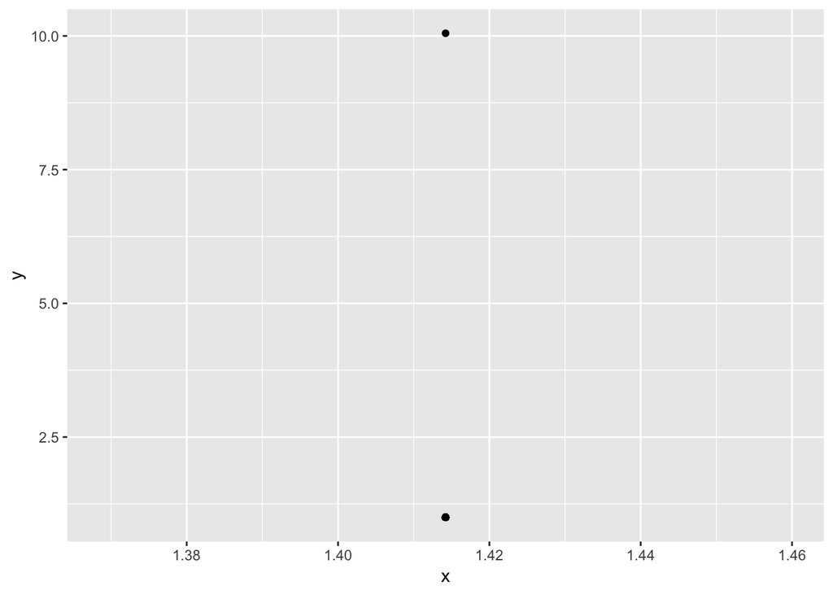

```r
ggplot(data.frame(x = x, y = y), aes(x = x, y = y)) +
  geom_point() +
  stat_smooth(method = "lm")
```

#### 13) Create simulated data and fit simple linear regression models to it.

```r
set.seed(1)
```

1. Using the `rnorm()` function, create a vector `x` containing 100 observations drawn from a N(0,1) distribution.

```r
x <- rnorm(100)
```

2. Using the `rnorm()` function, create a vector `eps` containing 100 observations drawn from a N(0,0.25) distribution, i.e. a normal distribution with mean zero and variance 0.25.

```r
eps <- rnorm(100, sd = 0.25)
```

3. Using `x` and `eps`, generate a vector `y` according to the model `Y = -1 + 0.5X + eps`. What is the length of `y`? What are the values of `B_0` and `B_1` in this model?

```r
y <- -1 + 0.5 * x + eps
```

The length of `y` is 100 like `x` and `eps`. `B_0` and `B_1` are the constant coefficient and linear coefficient terms, respectively: `B_0 = -1` and `B_1 = 0.5`.

4. Create a scatterplot of `x` vs `y`.

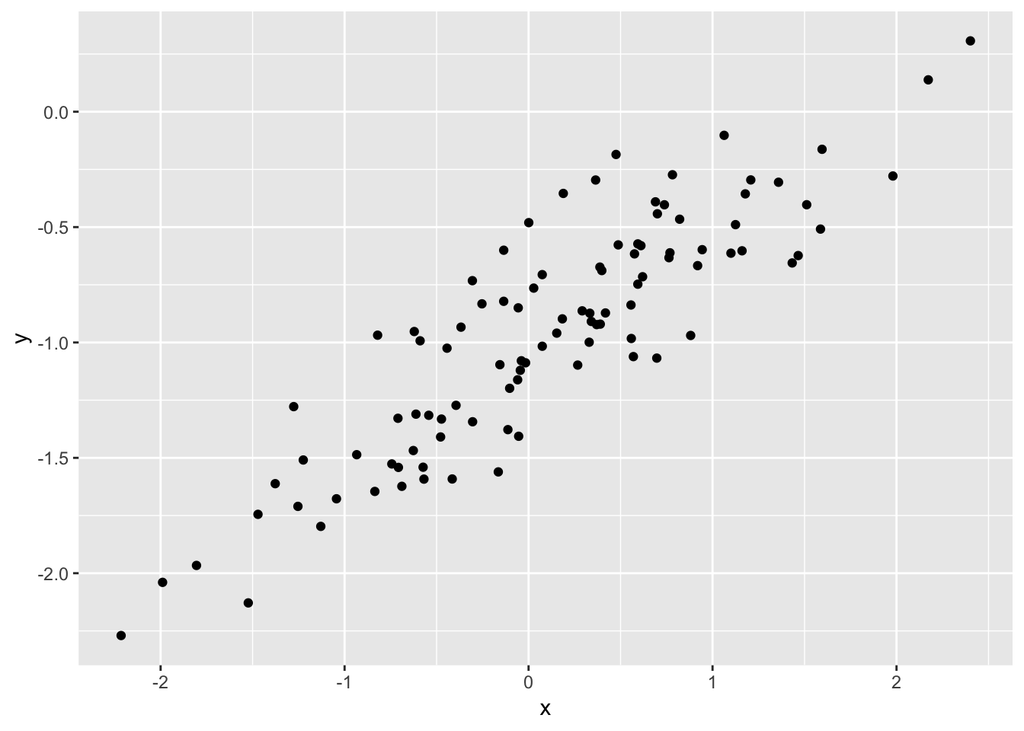

```r
ggplot(data.frame(x = x, y = y), aes(x = x, y = y)) +
  geom_point()
```

5. Fit a least squares linear model to predict `y` using `x`. Comment on the model obtained. How do the coefficients compare to (c)?

```r
lm_13e <- lm(y ~ x)
summary(lm_13e)
```

```
##
## Call:
## lm(formula = y ~ x)
##
## Residuals:
##      Min       1Q   Median       3Q      Max
## -0.46921 -0.15344 -0.03487  0.13485  0.58654
##
## Coefficients:
##             Estimate Std. Error t value Pr(>|t|)
## (Intercept) -1.00942    0.02425  -41.63   <2e-16 ***
## x            0.49973    0.02693   18.56   <2e-16 ***
## ---
## Signif. codes:  0 '***' 0.001 '**' 0.01 '*' 0.05 '.' 0.1 ' ' 1
##
## Residual standard error: 0.2407 on 98 degrees of freedom
## Multiple R-squared:  0.7784, Adjusted R-squared:  0.7762
## F-statistic: 344.3 on 1 and 98 DF,  p-value: < 2.2e-16
```

6. Display the least squares line on the scatterplot obtained in (d). Draw the population regression line on the plot in a different color.

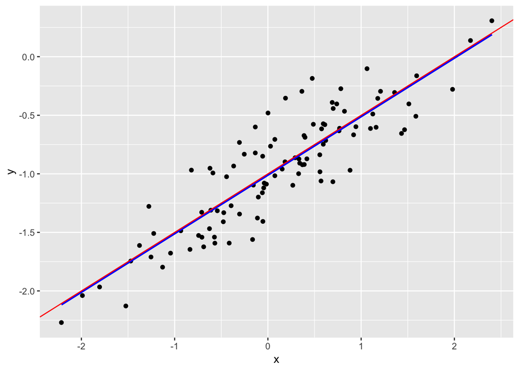

```r
ggplot(data.frame(x = x, y = y), aes(x = x, y = y)) +
  geom_point() +
  geom_smooth(method = "lm", formula = y ~ x, color = "blue", se = FALSE) +
  geom_abline(slope = 0.5, intercept = -1, color = "red")
```

7. Now fit a polynomial regression model using `x` and `x^2`. Is there evidence that the quadratic term improves the model?

```r
lm_13g <- lm(y ~ x + I(x^2))
summary(lm_13g)
```

```
##
## Call:
## lm(formula = y ~ x + I(x^2))
##
## Residuals:
##     Min      1Q  Median      3Q     Max
## -0.4913 -0.1563 -0.0322  0.1451  0.5675
##
## Coefficients:
##             Estimate Std. Error t value Pr(>|t|)
## (Intercept) -0.98582    0.02941 -33.516   <2e-16 ***
## x            0.50429    0.02700  18.680   <2e-16 ***
## I(x^2)      -0.02973    0.02119  -1.403    0.164
## ---
## Signif. codes:  0 '***' 0.001 '**' 0.01 '*' 0.05 '.' 0.1 ' ' 1
##
## Residual standard error: 0.2395 on 97 degrees of freedom
## Multiple R-squared:  0.7828, Adjusted R-squared:  0.7784
## F-statistic: 174.8 on 2 and 97 DF,  p-value: < 2.2e-16
```

The residual standard error and the R-squared values stayed nearly the same; the coeficient for the quadratic term was not statistically significant.

8. Repeat (a)-(f), generating an `eps` with less noise. Comment on the results.

```r
x <- rnorm(100)
eps <- rnorm(100, sd = 0.1)
y <- -1 + 0.5 * x + eps

lm_13h <- lm(y ~ x)
summary(lm_13h)
```

```
##
## Call:
## lm(formula = y ~ x)
##
## Residuals:
##       Min        1Q    Median        3Q       Max
## -0.274179 -0.056139 -0.001749  0.067973  0.184843
##
## Coefficients:
##              Estimate Std. Error t value Pr(>|t|)
## (Intercept) -0.995155   0.009910 -100.42   <2e-16 ***
## x            0.510622   0.009626   53.05   <2e-16 ***
## ---
## Signif. codes:  0 '***' 0.001 '**' 0.01 '*' 0.05 '.' 0.1 ' ' 1
##
## Residual standard error: 0.09906 on 98 degrees of freedom
## Multiple R-squared:  0.9663, Adjusted R-squared:  0.966
## F-statistic:  2814 on 1 and 98 DF,  p-value: < 2.2e-16
```

The RSE value is lower and the R-squared values higher for the simple linear fit in the case of `eps` having less noise.

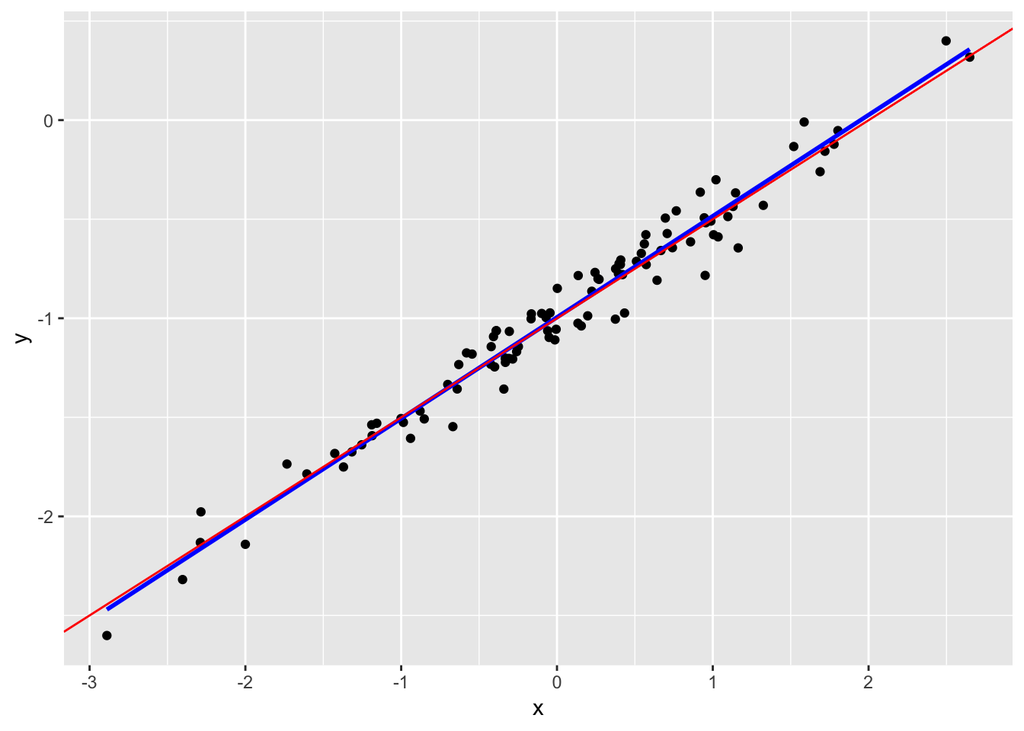

```r
ggplot(data.frame(x = x, y = y), aes(x = x, y = y)) +
  geom_point() +
  geom_smooth(method = "lm", formula = y ~ x, se = FALSE, color = "blue") +
  geom_abline(slope = 0.5, intercept = -1, color = "red")
```

```r
lm_13h2 <- lm(y ~ x + I(x^2))
summary(lm_13h2)
```

```
##
## Call:
## lm(formula = y ~ x + I(x^2))
##
## Residuals:
##       Min        1Q    Median        3Q       Max
## -0.274130 -0.055316 -0.002125  0.065771  0.193120
##
## Coefficients:
##              Estimate Std. Error t value Pr(>|t|)
## (Intercept) -0.992782   0.011971 -82.929   <2e-16 ***
## x            0.510193   0.009744  52.362   <2e-16 ***
## I(x^2)      -0.002227   0.006241  -0.357    0.722
## ---
## Signif. codes:  0 '***' 0.001 '**' 0.01 '*' 0.05 '.' 0.1 ' ' 1
##
## Residual standard error: 0.0995 on 97 degrees of freedom
## Multiple R-squared:  0.9664, Adjusted R-squared:  0.9657
## F-statistic:  1394 on 2 and 97 DF,  p-value: < 2.2e-16
```

Again, the RSE and R-squared values do not improve with the addition of a quadratic term. The p-value of the quadratic coefficient is much larger than in (g).

1. Repeat (a)-(f), generating an `eps` with more noise. Commend on the results.

```r
x <- rnorm(100)
eps <- rnorm(100, sd = 1)
y <- -1 + 0.5 * x + eps

lm_13i <- lm(y ~ x)
summary(lm_13i)
```

```
##
## Call:
## lm(formula = y ~ x)
##
## Residuals:
##      Min       1Q   Median       3Q      Max
## -2.51014 -0.60549  0.02065  0.70483  2.08980
##
## Coefficients:
##             Estimate Std. Error t value Pr(>|t|)
## (Intercept) -1.04745    0.09676 -10.825  < 2e-16 ***
## x            0.42505    0.08310   5.115 1.56e-06 ***
## ---
## Signif. codes:  0 '***' 0.001 '**' 0.01 '*' 0.05 '.' 0.1 ' ' 1
##
## Residual standard error: 0.9671 on 98 degrees of freedom
## Multiple R-squared:  0.2107, Adjusted R-squared:  0.2027
## F-statistic: 26.16 on 1 and 98 DF,  p-value: 1.56e-06
```

RSE went up while R-squared went down. The intercept and x coefficients are still significant and both of their 95% confidence intervals contain the coefficients of the population regression line.

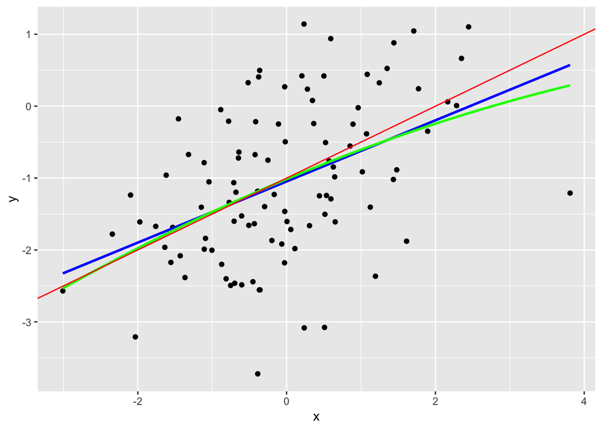

```r
ggplot(data.frame(x = x, y = y), aes(x = x, y = y)) +
  geom_point() +
  geom_smooth(method = "lm", formula = y ~ x, color = "blue", se = FALSE) +
  geom_smooth(method = "lm", formula = y ~ x + I(x^2), color = "green", se = FALSE) +
  geom_abline(slope = 0.5, intercept = -1, color = "red")
```

```r
lm_13i2 <- lm(y ~ x + I(x^2))
summary(lm_13i2)
```

```
##
## Call:
## lm(formula = y ~ x + I(x^2))
##
## Residuals:
##      Min       1Q   Median       3Q      Max
## -2.53612 -0.62004  0.00828  0.75138  2.05661
##
## Coefficients:
##             Estimate Std. Error t value Pr(>|t|)
## (Intercept) -1.01481    0.11669  -8.697 8.68e-14 ***
## x            0.43295    0.08487   5.101 1.68e-06 ***
## I(x^2)      -0.02385    0.04724  -0.505    0.615
## ---
## Signif. codes:  0 '***' 0.001 '**' 0.01 '*' 0.05 '.' 0.1 ' ' 1
##
## Residual standard error: 0.9708 on 97 degrees of freedom
## Multiple R-squared:  0.2128, Adjusted R-squared:  0.1965
## F-statistic: 13.11 on 2 and 97 DF,  p-value: 9.137e-06
```

Again, not much changes with the RSE or the R-squared values. The coefficient for the quadratic term is not statistically significant.

10. What are the confidence intervals for `B_0` and `B_1` based on the original data set, the noiser data set, and the less noisy data set? Explain.

#### 14) This problem focuses on the collinearity problem.

1. Perform the following commands:

```r
set.seed(1)
x1 = runif(100)
x2 = 0.5 * x1 + rnorm(100) / 10
y = 2 + 2 * x1 + 0.3 * x2 + rnorm(100)
```

This linear model is of the form `y = B_0 + B_1 * x_1 + B_2 * x_2 + eps`.

2. What is the relationship between `x1` and `x2`? Create a scatterplot.

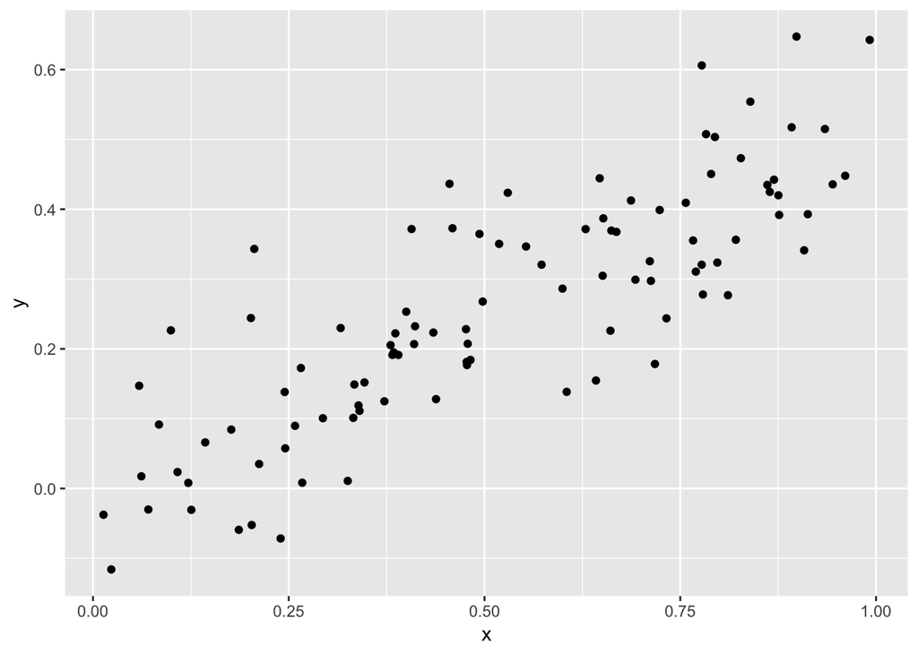

```r
ggplot(data.frame(x = x1, y = x2), aes(x, y)) +
  geom_point()
```

There is a strong positive correlation between `x1` and `x2`:

```r
cor(x1, x2)
```

```
## [1] 0.8351212
```

3. Fit a least squares regression to predict `y` using `x1` and `x2`, describe the result.

```r
lm_14c <- lm(y ~ x1 + x2)
summary(lm_14c)
```

```
##
## Call:
## lm(formula = y ~ x1 + x2)
##
## Residuals:
##     Min      1Q  Median      3Q     Max
## -2.8311 -0.7273 -0.0537  0.6338  2.3359
##
## Coefficients:
##             Estimate Std. Error t value Pr(>|t|)
## (Intercept)   2.1305     0.2319   9.188 7.61e-15 ***
## x1            1.4396     0.7212   1.996   0.0487 *
## x2            1.0097     1.1337   0.891   0.3754
## ---
## Signif. codes:  0 '***' 0.001 '**' 0.01 '*' 0.05 '.' 0.1 ' ' 1
##
## Residual standard error: 1.056 on 97 degrees of freedom
## Multiple R-squared:  0.2088, Adjusted R-squared:  0.1925
## F-statistic:  12.8 on 2 and 97 DF,  p-value: 1.164e-05
```

The null hypothesis that there is no relationship between the predictors and the r esponse can be rejected at a significance level of 0.001. However, only x1 has a statistically significant coefficent at the 0.05 level. The p value of the x2 coefficient is 0.38.

Recall that the population regression line is `y = 2 + 2 * x_1 + 0.3 * x_2`. Assuming a normal distribution of the coefficients in the model, the true values of the intercept and the x1 coefficient are within one standard deviation of the true coefficients. The x2 coefficient is as well, but 0 is also within one standard deviation of the approximate value.

4. Now fit a least squares regression to predict `y` using only `x1`. Comment on your results. Can you reject the null hypothesis `B_1 = 0`?

```r
lm_14d <- lm(y ~ x1)
summary(lm_14d)
```

```
##
## Call:
## lm(formula = y ~ x1)
##
## Residuals:
##      Min       1Q   Median       3Q      Max
## -2.89495 -0.66874 -0.07785  0.59221  2.45560
##
## Coefficients:
##             Estimate Std. Error t value Pr(>|t|)
## (Intercept)   2.1124     0.2307   9.155 8.27e-15 ***
## x1            1.9759     0.3963   4.986 2.66e-06 ***
## ---
## Signif. codes:  0 '***' 0.001 '**' 0.01 '*' 0.05 '.' 0.1 ' ' 1
##
## Residual standard error: 1.055 on 98 degrees of freedom
## Multiple R-squared:  0.2024, Adjusted R-squared:  0.1942
## F-statistic: 24.86 on 1 and 98 DF,  p-value: 2.661e-06
```

The significance level at which the null hypothesis that `B_1 = 0` can be rejected is higher than the previous model when `x_2` was included. The R-squared values only slightly dropped.

5. Now fit a least squares regression to predict `y` using only `x2`. Comment on your results. Can you reject the null hypothesis `B_2 = 0`?

```r
lm_14e <- lm(y ~ x2)
summary(lm_14e)
```

```
##
## Call:
## lm(formula = y ~ x2)
##
## Residuals:
##      Min       1Q   Median       3Q      Max
## -2.62687 -0.75156 -0.03598  0.72383  2.44890
##
## Coefficients:
##             Estimate Std. Error t value Pr(>|t|)
## (Intercept)   2.3899     0.1949   12.26  < 2e-16 ***
## x2            2.8996     0.6330    4.58 1.37e-05 ***
## ---
## Signif. codes:  0 '***' 0.001 '**' 0.01 '*' 0.05 '.' 0.1 ' ' 1
##
## Residual standard error: 1.072 on 98 degrees of freedom
## Multiple R-squared:  0.1763, Adjusted R-squared:  0.1679
## F-statistic: 20.98 on 1 and 98 DF,  p-value: 1.366e-05
```

R-squared values are lower; the null hypothesis that `B_2 = 0` can be rejected, but at a lower level than `B_1 = 0` in (d).

6. Do the results in (c)-(e) contradict each other? Explain your answer.

It is surprising that the p-values for x1 and x2 are much higher when they are included in the model together in (c) than when they are included separately in (d)-(e). However, we know that x1 and x2 are highly correlated due to how they were constructed. Because of this, it is hard to distinguish their effects when regressed upon together.

Recall that colinearity can be tested for by calculating the VIF for each variable using the formula `VIF(Bi) = 1 / (1 - R^2_{X_i|X_-i})` where `R^2_{X_i|X_-i}` is the R-squared from a regression of `x_i` onto all of the other predictors. An R-squared close to 1 (and so a large VIF) indicates collinearity.

```r
lm_14e <- lm(x2 ~ x1)
1 / (1 - summary(lm_14e)$r.squared)
```

```
## [1] 3.304993
```

```r
lm_14e2 <- lm(x1 ~ x2)
1 / (1 - summary(lm_14e2)$r.squared)
```

```
## [1] 3.304993
```

Same result.